# The LongTable Class

Petr Smirnov and Christopher Eeles

Princess Margaret Cancer Centre, University Health Network, Toronto Canada

petr.smirnov@uhnresearch.ca  
christopher.eeles@uhnresearch.ca

23 October 2020

#### Package

CoreGx 1.1.5

# 1 Why Do We Need A New Class?

The current implementation for the `@sensitivity` slot in a `PharmacoSet` has some limitations.

Firstly, it does not natively support dose-response experiments with multiple drugs and/or cancer cell lines. As a result we have not been able to include this data into a PharmacoSet thus far.

Secondly, drug combination data has the potential to scale to high dimensionality. As a result we need an object that is highly performant to ensure computations on such data can be completed in a timely manner.

# 2 Design Philosophy

The current use case is supporting drug and cell-line combinations in `PharmacoGx`, but we wanted to create something flexible enough to fit other use cases. As such, the current class makes no mention of drugs or cell-lines, nor anything specifically related to Bioinformatics or Computation Biology. Rather, we tried to design a general purpose data structure which could support high dimensional data for any use case.

Our design takes the best aspects of the `SummarizedExperiment` and `MultiAssayExperiment` class and implements them using the `data.table` package, which provides an R API to a rich set of tools for high performance data processing implemented in C.

# 3 Anatomy of a LongTable

## 3.1 Class Diagram

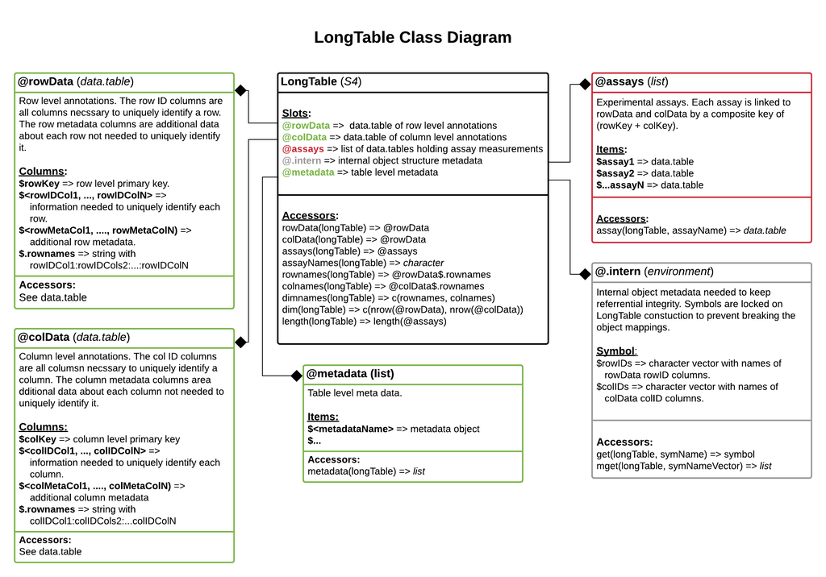

We have borrowed directly from the `SummarizedExperiment` class for the `rowData`, `colData`, `metadata` and `assays` slot names. We also implemented the `SummarizedExperiment` accessor generics for the `LongTable`.

## 3.2 Object Structure and Cardinality

There are, however, some important differences which make this object more flexible when dealing with high dimensional data.

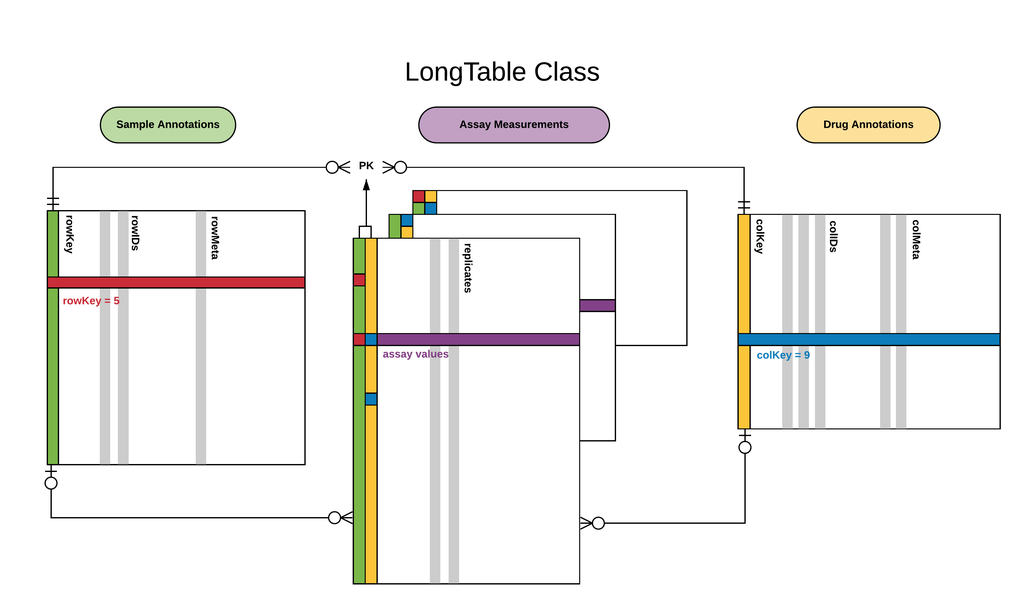

Unlike a `SummarizedExperiment`, there are three distinct classes of columns in `rowData` and `colData`.

The first is the `rowKey` or `colKey`, these are implemented internally to keep mappings between each assay and the associated samples or drugs; these will not be returned by the accessors by default. The second is the `rowIDs` and `colID`, these hold all of the information necessary to uniquely identify a row or column and are used to generate the `rowKey` and `colKey`. Finally, there are the `rowMeta` and `colMeta` columns, which store any additional data about samples or drugs not required to uniquely identify a row in either table.

Within the assays the `rowKey` and `colKey` are combined to form a primary key for each assay row. This is required because each assay is stored in ‘long’ format, instead of wide format as in the assay matrices within a `SummarizedExperiment`. Thanks to the fast implementation of binary search within the `data.table` package, assay tables can scale up to tens or even hundreds of millions of rows while still being relatively performant.

# 4 Building a LongTable

he current implementation of the `buildLongTable` function is able to assemble a `LongTable` object from two sources. The first is a single large table with all assays, row and column data contained within it. This is the structure of the Merck drug combination data that has been used to test the data structure thus far.

```r
filePath <- '../data/merckLongTable.csv'
merckDT <- fread(filePath, na.strings=c('NULL'))
colnames(merckDT)
```

```
##  [1] "cell_line"        "combination_name" "BatchID"          "drugA_name"
##  [5] "drugA Conc (uM)"  "drugB_name"       "drugB Conc (uM)"  "viability1"
##  [9] "viability2"       "viability3"       "viability4"       "mu/muMax"
## [13] "X/X0"
```

```r
knitr::kable(head(merckDT)[, 1:5])
```

| cell_line | combination_name | BatchID | drugA_name | drugA Conc (uM) |
| --- | --- | --- | --- | --- |
| A2058 | 5-FU & ABT-888 | 1 | 5-FU | 0.35 |
| A2058 | 5-FU & BEZ-235 | 1 | 5-FU | 0.35 |
| A2058 | 5-FU & Bortezomib | 1 | 5-FU | 0.35 |
| A2058 | 5-FU & Dasatinib | 1 | 5-FU | 0.35 |
| A2058 | 5-FU & L778123 | 1 | 5-FU | 0.35 |
| A2058 | 5-FU & geldanamycin | 1 | 5-FU | 0.35 |

```r
knitr::kable(head(merckDT)[, 5:ncol(merckDT)])
```

| drugA Conc (uM) | drugB_name | drugB Conc (uM) | viability1 | viability2 | viability3 | viability4 | mu/muMax | X/X0 |
| --- | --- | --- | --- | --- | --- | --- | --- | --- |
| 0.35 | ABT-888 | 0.35000 | 0.971 | 1.090 | 0.949 | 0.996 | 0.992 | 0.988 |
| 0.35 | BEZ-235 | 0.00450 | 0.921 | 0.947 | 0.915 | 0.956 | 0.965 | 0.953 |
| 0.35 | Bortezomib | 0.00045 | 0.983 | 0.962 | 0.950 | 0.954 | 0.978 | 0.970 |
| 0.35 | Dasatinib | 0.02400 | 0.798 | 0.778 | 0.946 | 0.312 | 0.879 | 0.846 |
| 0.35 | L778123 | 0.32500 | 1.117 | 1.020 | 0.920 | 0.927 | 0.986 | 0.981 |
| 0.35 | geldanamycin | 0.02230 | 1.023 | 1.018 | 0.912 | 0.897 | 0.982 | 0.975 |

We can see from the last two slides that all the data related to the treatment response experiment is contained within this table.

## 4.1 Single Assays Table

To build a `LongTable` object from this file:

```r
rowDataCols <- list(
    c(cell_line1="cell_line", BatchID="BatchID"))
colDataCols <- list(
    c(drug1='drugA_name', drug2='drugB_name',
     drug1dose='drugA Conc (uM)', drug2dose='drugB Conc (uM)'),
    c(comboName='combination_name'))
assayCols <- list(viability=paste0('viability', seq_len(4)),
                  viability_summary=c('mu/muMax', 'X/X0'))
longTable <- buildLongTable(from=filePath, rowDataCols,
                            colDataCols, assayCols)
```

```
## < LongTable >
## dim:  8 583
## assays(2): viability viability_summary
## rownames(8): A2058:1 A2780:1 A2780:2 ... A427:1 CAOV3:1 CAOV3:2
## rowData(2): cell_line1 BatchID
## colnames(583): 5-FU:ABT-888:0.35:0.35 5-FU:AZD1775:0.35:0.0325 5-FU:BEZ-235:0.35:0.0045 ... geldanamycin:SN-38:0.0223:0.000115 geldanamycin:Sorafenib:0.0223:2.5 geldanamycin:Topotecan:0.0223:0.0223
## colData(5): drug1 drug2 drug1dose drug2dose comboName
## metadata(0): none
```

This function will also work if directly passed a `data.table` or `data.frame` object:

```
## [1] "All equal? TRUE"
```

## 4.2 Multiple Assay Tables

The second option for building a `LongTable` is to pass it a list of different assays with a shared set of row and column identifiers. We haven’t had a chance to testing this functionality with real data yet, but do have a toy example.

```r
assayList <- assays(longTable, withDimnames=TRUE, metadata=TRUE, key=FALSE)
assayList$new_viability <- assayList$viability  # Add a fake additional assay
assayCols$new_viability <-  assayCols$viability  # Add column names for fake assay
longTable2 <- buildLongTable(from=assayList, lapply(rowDataCols, names), lapply(colDataCols, names), assayCols)
```

```
## < LongTable >
## dim:  8 583
## assays(3): viability viability_summary new_viability
## rownames(8): A2058:1 A2780:1 A2780:2 ... A427:1 CAOV3:1 CAOV3:2
## rowData(2): cell_line1 BatchID
## colnames(583): 5-FU:ABT-888:0.35:0.35 5-FU:AZD1775:0.35:0.0325 5-FU:BEZ-235:0.35:0.0045 ... geldanamycin:SN-38:0.0223:0.000115 geldanamycin:Sorafenib:0.0223:2.5 geldanamycin:Topotecan:0.0223:0.0223
## colData(5): drug1 drug2 drug1dose drug2dose comboName
## metadata(0): none
```

We can see that a new assay has been added to the `LongTable` object when passed a list of assay tables containing the required row and column IDs. Additionally, any row or column IDs not already in rowData or colData will be appended to these slots automatically!

# 5 LongTable Object

## 5.1 Row and Column Names

```r
head(rownames(longTable))
```

```
## [1] "A2058:1" "A2780:1" "A2780:2" "A375:1"  "A375:2"  "A427:1"
```

We see that the rownames for the Merck `LongTable` are the cell line name pasted to the batch id.

```r
head(colnames(longTable))
```

```
## [1] "5-FU:ABT-888:0.35:0.35"        "5-FU:AZD1775:0.35:0.0325"
## [3] "5-FU:BEZ-235:0.35:0.0045"      "5-FU:Bortezomib:0.35:0.00045"
## [5] "5-FU:Dasatinib:0.35:0.024"     "5-FU:Dinaciclib:0.35:0.000925"
```

For the column names, a similar pattern is followed by combining the colID columns in the form ‘drug1:drug2:drug1dose:drug2dose’.

## 5.2 `data.frame` Subsetting

We can subset a `LongTable` using the same row and column name syntax as with a `data.frame` or `matrix`.

```r
row <- rownames(longTable)[1]
columns <- colnames(longTable)[1:2]
longTable[row, columns]
```

```
## < LongTable >
## dim:  1 2
## assays(2): viability viability_summary
## rownames(1): A2058:1
## rowData(2): cell_line1 BatchID
## colnames(2): 5-FU:ABT-888:0.35:0.35 5-FU:AZD1775:0.35:0.0325
## colData(5): drug1 drug2 drug1dose drug2dose comboName
## metadata(0): none
```

### 5.2.1 Regex Queries

However, unlike a `data.frame` or `matrix` this subsetting also accepts partial row and column names as well as regex queries.

```r
head(rowData(longTable), 3)
```

```
##    cell_line1 BatchID
## 1:      A2058       1
## 2:      A2780       1
## 3:      A2780       2
```

```r
head(colData(longTable), 3)
```

```
##    drug1   drug2 drug1dose drug2dose      comboName
## 1:  5-FU ABT-888      0.35    0.3500 5-FU & ABT-888
## 2:  5-FU AZD1775      0.35    0.0325 5-FU & AZD1775
## 3:  5-FU BEZ-235      0.35    0.0045 5-FU & BEZ-235
```

For example, if we want to get all instance where ‘5-FU’ is the drug:

```r
longTable[, '5-FU']
```

```
## < LongTable >
## dim:  5 22
## assays(2): viability viability_summary
## rownames(5): A2058:1 A2780:1 A375:1 A427:1 CAOV3:1
## rowData(2): cell_line1 BatchID
## colnames(22): 5-FU:ABT-888:0.35:0.35 5-FU:AZD1775:0.35:0.0325 5-FU:BEZ-235:0.35:0.0045 ... 5-FU:geldanamycin:0.35:0.0223 MK-4541:5-FU:0.045:0.35 MRK-003:5-FU:0.35:0.35
## colData(5): drug1 drug2 drug1dose drug2dose comboName
## metadata(0): none
```

This has matched all colnames where 5-FU was in either drug1 or drug2. If we only want to match drug1, we have several options:

```r
all.equal(longTable[, '5-FU:*:*:*'], longTable[, '^5-FU'])
```

```
## [1] TRUE
```

## 5.3 `data.table` Subsetting

In addition to regex queries, a `LongTable` object supports arbitrarily complex subset queries using the `data.table` API. To access this API, you will need to use the `.` function, which allows you to pass raw R expressions to be evaluated inside the `i` and `j` arguments for `dataTable[i, j]`.

```r
longTable[.(cell_line1 == 'CAOV3'),  # row query
          .(drug1 == 'Temozolomide' & drug2 %in% c('Lapatinib', 'Bortezomib'))]  # column query
```

```
## < LongTable >
## dim:  1 2
## assays(2): viability viability_summary
## rownames(1): CAOV3:1
## rowData(2): cell_line1 BatchID
## colnames(2): Temozolomide:Bortezomib:2.75:0.00045 Temozolomide:Lapatinib:2.75:0.055
## colData(5): drug1 drug2 drug1dose drug2dose comboName
## metadata(0): none
```

We can also invert matches or subset on other columns in `rowData` or `colData`:

```r
subLongTable <-
  longTable[.(BatchID != 2),
            .(drug1 == 'Temozolomide' & drug2 != 'Lapatinib')]
```

To show that it works as expected:

```r
print(paste0('BatchID: ', paste0(unique(rowData(subLongTable)$BatchID), collapse=', ')))
```

```
## [1] "BatchID: 1"
```

```r
print(paste0('drug2: ', paste0(unique(colData(subLongTable)$drug2), collapse=', ')))
```

```
## [1] "drug2: ABT-888, AZD1775, BEZ-235, Bortezomib, Dasatinib, Dinaciclib, Erlotinib, MK-2206, MK-4827, MK-5108, MK-8669, MK-8776, Oxaliplatin, PD325901, SN-38, Sorafenib, Topotecan, geldanamycin"
```

# 6 Accessor Methods

## 6.1 rowData

```r
head(rowData(longTable), 3)
```

```
##    cell_line1 BatchID
## 1:      A2058       1
## 2:      A2780       1
## 3:      A2780       2
```

```r
head(rowData(longTable, key=TRUE), 3)
```

```
##    cell_line1 BatchID rowKey
## 1:      A2058       1      1
## 2:      A2780       1      2
## 3:      A2780       2      3
```

## 6.2 colData

```r
head(colData(longTable), 3)
```

```
##    drug1   drug2 drug1dose drug2dose      comboName
## 1:  5-FU ABT-888      0.35    0.3500 5-FU & ABT-888
## 2:  5-FU AZD1775      0.35    0.0325 5-FU & AZD1775
## 3:  5-FU BEZ-235      0.35    0.0045 5-FU & BEZ-235
```

```r
head(colData(longTable, key=TRUE), 3)
```

```
##    drug1   drug2 drug1dose drug2dose      comboName colKey
## 1:  5-FU ABT-888      0.35    0.3500 5-FU & ABT-888      1
## 2:  5-FU AZD1775      0.35    0.0325 5-FU & AZD1775      2
## 3:  5-FU BEZ-235      0.35    0.0045 5-FU & BEZ-235      3
```

## 6.3 assays

```r
assays <- assays(longTable)
assays[[1]]
```

```
##       viability1 viability2 viability3 viability4 rowKey colKey
##    1:      0.971      1.090      0.949      0.996      1      1
##    2:      0.893      1.106      0.907      1.029      1      2
##    3:      0.921      0.947      0.915      0.956      1      3
##    4:      0.983      0.962      0.950      0.954      1      4
##    5:      0.798      0.778      0.946      0.312      1      5
##   ---
## 2911:      0.824      0.817      0.988      0.835      8    499
## 2912:      0.926      0.871      1.069      0.995      8    560
## 2913:      0.815      0.845      0.753      0.677      8    561
## 2914:      0.670      0.779      0.647      0.822      8    568
## 2915:      1.028      1.020      1.021      1.032      8    574
```

```r
assays[[2]]
```

```
##       mu/muMax  X/X0 rowKey colKey
##    1:    0.992 0.988      1      1
##    2:    0.984 0.977      1      2
##    3:    0.965 0.953      1      3
##    4:    0.978 0.970      1      4
##    5:    0.879 0.846      1      5
##   ---
## 2911:    0.757 0.714      8    499
## 2912:    0.947 0.930      8    560
## 2913:    0.683 0.645      8    561
## 2914:    0.581 0.559      8    568
## 2915:    1.032 1.045      8    574
```

```r
assays <- assays(longTable, withDimnames=TRUE)
colnames(assays[[1]])
```

```
##  [1] "drug1"      "drug2"      "drug1dose"  "drug2dose"  "comboName"
##  [6] "cell_line1" "BatchID"    "viability1" "viability2" "viability3"
## [11] "viability4"
```

```r
assays <- assays(longTable, withDimnames=TRUE, metadata=TRUE)
colnames(assays[[2]])
```

```
## [1] "drug1"      "drug2"      "drug1dose"  "drug2dose"  "comboName"
## [6] "cell_line1" "BatchID"    "mu/muMax"   "X/X0"
```

```r
assayNames(longTable)
```

```
## [1] "viability"         "viability_summary"
```

Using these names we can access specific assays within a `LongTable`.

## 6.4 assay

```r
colnames(assay(longTable, 'viability'))
```

```
## [1] "viability1" "viability2" "viability3" "viability4" "rowKey"
## [6] "colKey"
```

```r
assay(longTable, 'viability')
```

```
##       viability1 viability2 viability3 viability4 rowKey colKey
##    1:      0.971      1.090      0.949      0.996      1      1
##    2:      0.893      1.106      0.907      1.029      1      2
##    3:      0.921      0.947      0.915      0.956      1      3
##    4:      0.983      0.962      0.950      0.954      1      4
##    5:      0.798      0.778      0.946      0.312      1      5
##   ---
## 2911:      0.824      0.817      0.988      0.835      8    499
## 2912:      0.926      0.871      1.069      0.995      8    560
## 2913:      0.815      0.845      0.753      0.677      8    561
## 2914:      0.670      0.779      0.647      0.822      8    568
## 2915:      1.028      1.020      1.021      1.032      8    574
```

```r
colnames(assay(longTable, 'viability', withDimnames=TRUE))
```

```
##  [1] "drug1"      "drug2"      "drug1dose"  "drug2dose"  "comboName"
##  [6] "cell_line1" "BatchID"    "viability1" "viability2" "viability3"
## [11] "viability4"
```

```r
assay(longTable, 'viability', withDimnames=TRUE)
```

```
##              drug1        drug2 drug1dose drug2dose                comboName
##    1:         5-FU      ABT-888    0.3500  0.350000           5-FU & ABT-888
##    2:         5-FU      AZD1775    0.3500  0.032500           5-FU & AZD1775
##    3:         5-FU      BEZ-235    0.3500  0.004500           5-FU & BEZ-235
##    4:         5-FU   Bortezomib    0.3500  0.000450        5-FU & Bortezomib
##    5:         5-FU    Dasatinib    0.3500  0.024000         5-FU & Dasatinib
##   ---
## 2911: Temozolomide    Erlotinib    2.7500  0.055000 Temozolomide & Erlotinib
## 2912:      Zolinza   Dinaciclib    0.0925  0.000925     Zolinza & Dinaciclib
## 2913:      Zolinza    Erlotinib    0.0925  0.055000      Zolinza & Erlotinib
## 2914:      Zolinza      MK-8776    0.0925  0.092500        Zolinza & MK-8776
## 2915:      Zolinza Temozolomide    0.0925  2.750000   Zolinza & Temozolomide
##       cell_line1 BatchID viability1 viability2 viability3 viability4
##    1:      A2058       1      0.971      1.090      0.949      0.996
##    2:      A2058       1      0.893      1.106      0.907      1.029
##    3:      A2058       1      0.921      0.947      0.915      0.956
##    4:      A2058       1      0.983      0.962      0.950      0.954
##    5:      A2058       1      0.798      0.778      0.946      0.312
##   ---
## 2911:      CAOV3       2      0.824      0.817      0.988      0.835
## 2912:      CAOV3       2      0.926      0.871      1.069      0.995
## 2913:      CAOV3       2      0.815      0.845      0.753      0.677
## 2914:      CAOV3       2      0.670      0.779      0.647      0.822
## 2915:      CAOV3       2      1.028      1.020      1.021      1.032
```